# Single Cell RNA-Seq : 02-Doublet detection

Alexander G Foote

2025-03-06

## Load packages

Doublets are cells that appear to be, but are not, real cells. There are two major types of doublets: heterotypic and homotypic. *Heterotypic doublets* are formed by cells with distinct transcriptional profiles. *Homotypic doublets* are formed by cells with similar transcriptional profiles. Heterotypic doublets are relatively easier to detect compared with homotypic doublets.

Depending on the protocols used to barcode single cells/nuclei, doublet rates vary significantly and it can reach as high as 40%. Experimental strategies have been developed to reduce the doublet rate, such as [cell hashing](https://genomebiology.biomedcentral.com/articles/10.1186/s13059-018-1603-1), and [MULTI-Seq](https://www.nature.com/articles/s41592-019-0433-8). However, these techniques require extra steps in sample preparation which leads to extra costs and time, and they do not guarantee to remove all doublets.

Naturally, removing doublets *in silico* is very appealing and there have been many tools/methods developed to achieve this: DoubletFinder, DoubletDetection(https://github.com/JonathanShor/DoubletDetection), [DoubletDecon](https://www.sciencedirect.com/science/article/pii/S2211124719312860), [demuxlet](https://www.nature.com/articles/nbt.4042), among others.

## Import data for DoubletFinder

DoubletFinder takes fully pre-processed data from Seurat (NormalizeData, FindVariableGenes, ScaleData, RunPCA, and RunUMAP) as input and the process should be done for each sample individually. The input data should be processed to remove low-quality cell clusters first.

```r
saline1 <- readRDS("/Users/alexanderfoote/dev/Projs/R/scRNA_analysis_7dpi_IAV/rds/saline1.std_pipeline_predoubletremoval_IAVseq.rds")
saline2 <- readRDS("/Users/alexanderfoote/dev/Projs/R/scRNA_analysis_7dpi_IAV/rds/saline2.std_pipeline_predoubletremoval_IAVseq.rds")
IAV <- readRDS("/Users/alexanderfoote/dev/Projs/R/scRNA_analysis_7dpi_IAV/rds/IAV.std_pipeline_predoubletremoval_IAVseq.rds")
```

## Parameter selection

In addition to the Seurat object, DoubletFinder takes a number of arguments. These are: * PCs: a vector of statistically significant PCs to use * pN: the number of artificially generated doublets (default = 0.25) * pK: PC neighborhood size used to compute network * nExp: threshold used to make doublet/singlet call

```r
#Saline1
saline1 <- FindNeighbors(saline1, dims = 1:50)
saline1 <- FindClusters(saline1, resolution = 0.5)
```

```
## Modularity Optimizer version 1.3.0 by Ludo Waltman and Nees Jan van Eck
##
## Number of nodes: 2797
## Number of edges: 97272
##
## Running Louvain algorithm...
## Maximum modularity in 10 random starts: 0.9085
## Number of communities: 12
## Elapsed time: 0 seconds
```

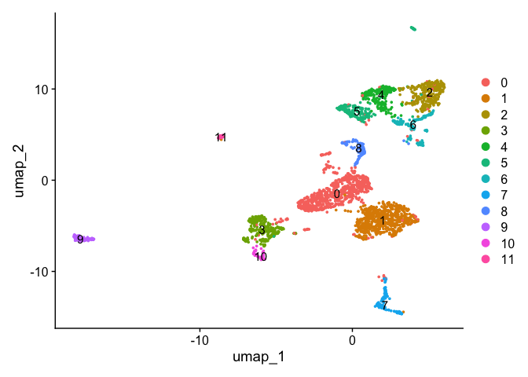

```r
DimPlot(saline1, reduction = "umap", label=TRUE, pt.size = 0.5)
```

```r
#Saline2
saline2 <- FindNeighbors(saline2, dims = 1:50)
saline2 <- FindClusters(saline2, resolution = 0.5)
```

```
## Modularity Optimizer version 1.3.0 by Ludo Waltman and Nees Jan van Eck
##
## Number of nodes: 5495
## Number of edges: 180880
##
## Running Louvain algorithm...
## Maximum modularity in 10 random starts: 0.9426
## Number of communities: 28
## Elapsed time: 0 seconds
```

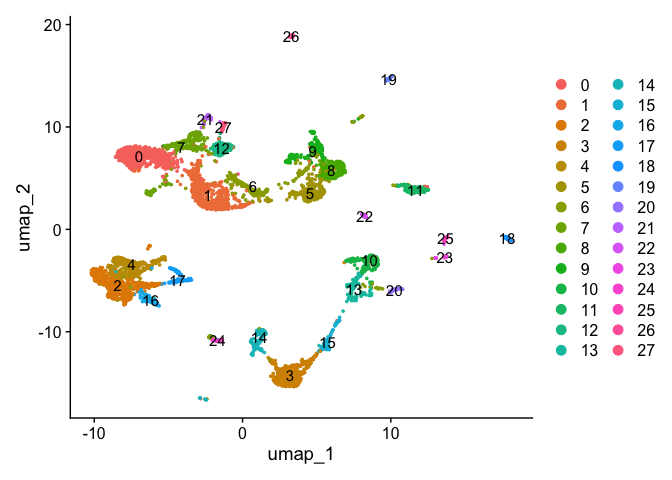

```r
DimPlot(saline2, reduction = "umap", label=TRUE, pt.size = 0.5)
```

```r
#IAV
IAV <- FindNeighbors(IAV, dims = 1:50)
IAV <- FindClusters(IAV, resolution = 0.5)
```

```
## Modularity Optimizer version 1.3.0 by Ludo Waltman and Nees Jan van Eck
##
## Number of nodes: 5774
## Number of edges: 184691
##
## Running Louvain algorithm...
## Maximum modularity in 10 random starts: 0.9259
## Number of communities: 29
## Elapsed time: 0 seconds
```

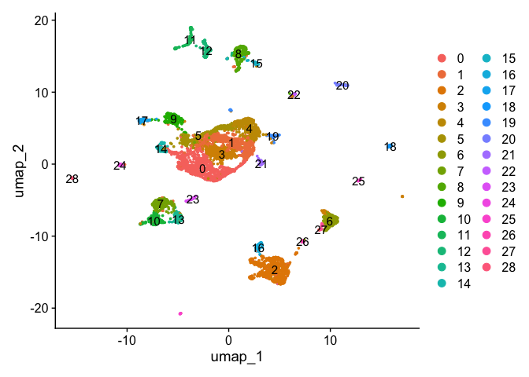

```r
DimPlot(IAV, reduction = "umap", label=TRUE, pt.size = 0.5)
```

## Check Compartments and Feature Counts

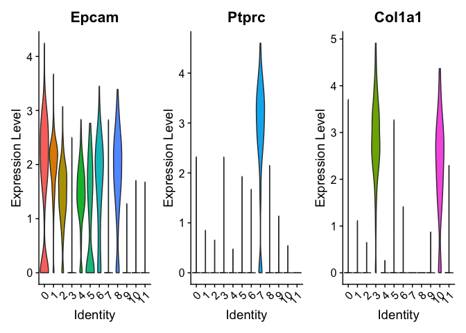

```r
#Compartments
VlnPlot(saline1,features=c("Epcam","Ptprc","Col1a1","Cldn5"),pt.size=0.0)
```

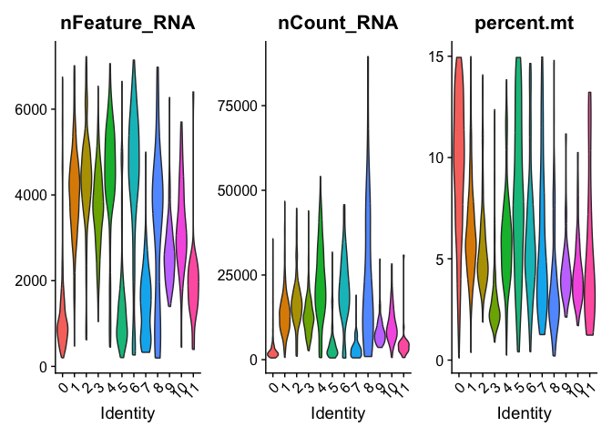

```r
#Feature Counts
VlnPlot(saline1,features=c("nFeature_RNA","nCount_RNA","percent.mt"),pt.size=0)
```

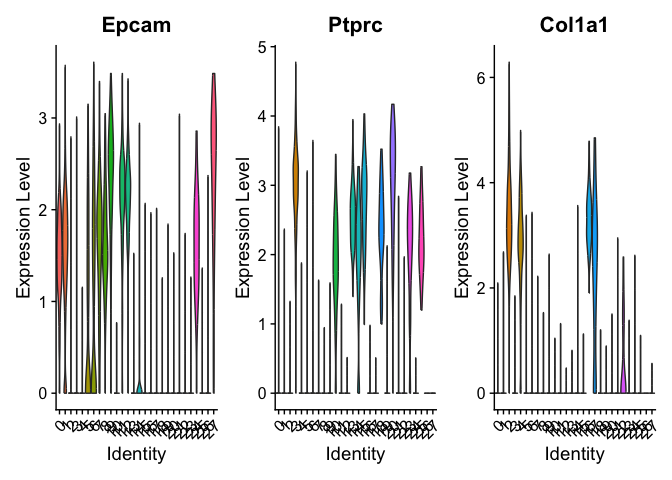

```r
#Compartments
VlnPlot(saline2,features=c("Epcam","Ptprc","Col1a1","Cldn5"),pt.size=0)
```

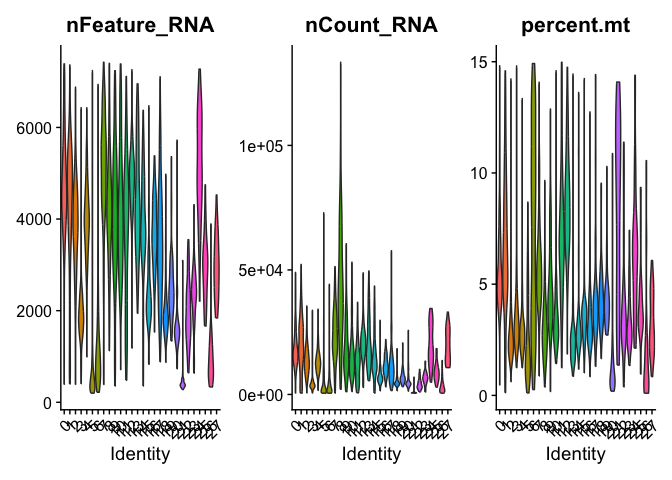

```r
#Feature Counts
VlnPlot(saline2,features=c("nFeature_RNA","nCount_RNA","percent.mt"),pt.size=0)
```

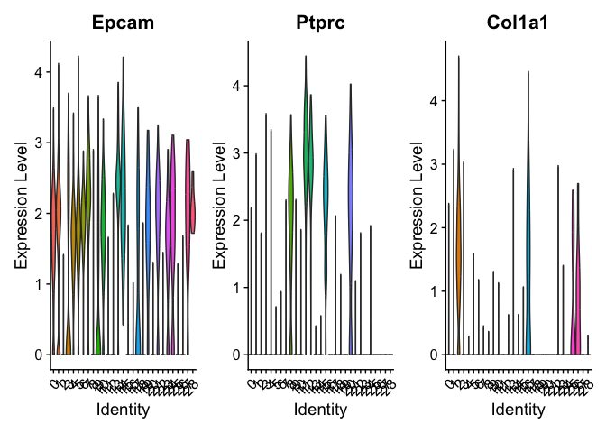

```r
#Compartments
VlnPlot(IAV,features=c("Epcam","Ptprc","Col1a1","Cldn5"),pt.size=0)
```

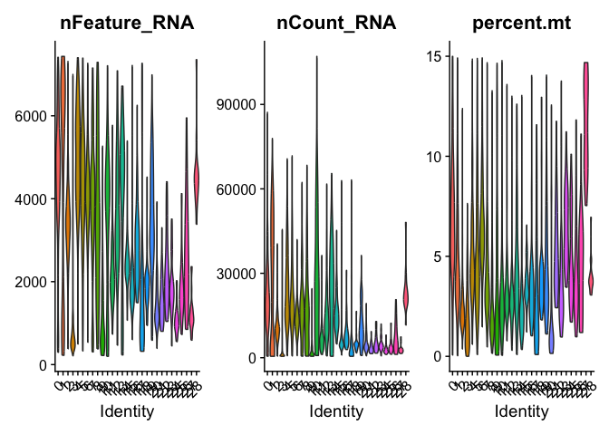

```r
#Feature Counts
VlnPlot(IAV,features=c("nFeature_RNA","nCount_RNA","percent.mt"),pt.size=0)
```

### Save object

```r
#setwd('/Users/alexanderfoote/R_Projects/scRNA_analysis_7dpi_postIAV/rds')
saveRDS(saline1, "saline1.std_pipeline_singlets_unrefined_mt15_IAVseq.rds")
saveRDS(saline2, "saline2.std_pipeline_singlets_unrefined_mt15_IAVseq.rds")
saveRDS(IAV, "IAV.std_pipeline_singlets_unrefined_mt15_IAVseq.rds")
```